# Test Uzunluğunun Təsiri: Spearman-Brown Prespesiya Formulası

Klassik Test Nəzəriyyəsi - Etibarlılığın Artırılması

Klassik Test Nəzəriyyəsi Kursu

2025-07-18

## 0.1 Dərsin Məqsədləri

✓ Spearman-Brown prespesiya formulasını anlamaq və tətbiq etmək  
✓ Test uzunluğu və etibarlılıq arasındakı riyazi əlaqəni mənimsəmək  
✓ Optimal test uzunluğunu təyin etmə metodlarını öyrənmək  
✓ Zaman və etibarlılıq arasındakı balansı qiymətləndirmək  
✓ R-da test uzunluğu simulyasiyalarını aparmaq

## 0.2 Əvvəlki Dərsdən Xatırladıqlarımız

**Dərs 13-də öyrəndiklərimiz:** - Item-total korrelyasiya və corrected versiyası - Alpha-if-item-deleted analizi - Bənd seçimi meyarları - Test optimallaşdırma strategiyaları

# 1 Spearman-Brown Prespesiya Formulası

## 1.1 Formulanın Mahiyyəti və Nəzəri Əsasları

**Spearman-Brown prespesiya formulası** test uzunluğunun etibarlılığa təsirini proqnozlaşdırır.

### 1.1.1 **ρₙₙ = nρ₁₁ / [1 + (n-1)ρ₁₁]**

Bu formulada: - **ρₙₙ** = n dəfə uzadılmış testin etibarlılığı - **n** = Test uzunluğu multiplikatoru - **ρ₁₁** = Orijinal testin etibarlılığı

```r
# Spearman-Brown formulası konseptual demonstrasiya
spearman_brown <- function(original_reliability, multiplier) {
  (multiplier * original_reliability) / (1 + (multiplier - 1) * original_reliability)
}

# Müxtəlif orijinal etibarlılıq səviyyələri
original_reliabilities <- c(0.50, 0.60, 0.70, 0.80, 0.90)
multipliers <- seq(1, 5, by = 0.5)

# Hesablamalar
sb_results <- expand.grid(
  Original_r = original_reliabilities,
  Multiplier = multipliers
) %>%
  mutate(
    Predicted_r = spearman_brown(Original_r, Multiplier),
    Original_Label = paste("r =", Original_r)
  )

kable(head(sb_results, 10),
      caption = "Spearman-Brown Formulası Nümunə Hesablamalar", digits = 3)
```

Spearman-Brown Formulası Nümunə Hesablamalar

| Original_r | Multiplier | Predicted_r | Original_Label |
| --- | --- | --- | --- |
| 0.5 | 1.0 | 0.500 | r = 0.5 |
| 0.6 | 1.0 | 0.600 | r = 0.6 |
| 0.7 | 1.0 | 0.700 | r = 0.7 |
| 0.8 | 1.0 | 0.800 | r = 0.8 |
| 0.9 | 1.0 | 0.900 | r = 0.9 |
| 0.5 | 1.5 | 0.600 | r = 0.5 |
| 0.6 | 1.5 | 0.692 | r = 0.6 |
| 0.7 | 1.5 | 0.778 | r = 0.7 |
| 0.8 | 1.5 | 0.857 | r = 0.8 |
| 0.9 | 1.5 | 0.931 | r = 0.9 |

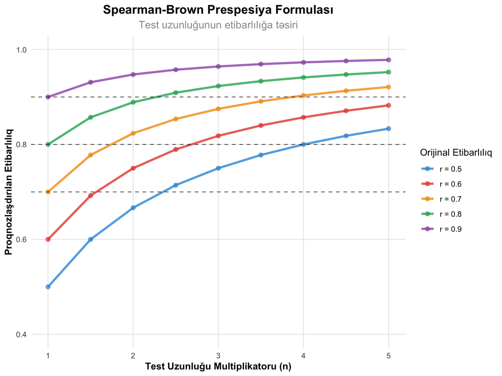

```r
# Formulanın vizuallaşdırılması
ggplot(sb_results, aes(x = Multiplier, y = Predicted_r, color = Original_Label)) +
  geom_line(size = 1.2, alpha = 0.8) +
  geom_point(size = 2, alpha = 0.7) +
  geom_hline(yintercept = c(0.70, 0.80, 0.90), linetype = "dashed", alpha = 0.6) +
  scale_color_manual(values = colors_basic[1:5]) +
  labs(title = "Spearman-Brown Prespesiya Formulası",
       subtitle = "Test uzunluğunun etibarlılığa təsiri",
       x = "Test Uzunluğu Multiplikatoru (n)",
       y = "Proqnozlaşdırılan Etibarlılıq",
       color = "Orijinal Etibarlılıq") +
  theme_clean() +
  xlim(1, 5) + ylim(0.4, 1.0)
```

## 1.2 Formulanın Riyazi Əsaslandırılması

```r
# Spearman-Brown formulasının nəzəri əsasları
theoretical_explanation <- data.frame(
  Komponent = c("Numerator (nρ₁₁)", "Denominator [1+(n-1)ρ₁₁]", "Nəticə (ρₙₙ)"),
  Riyazi_Mənası = c("Test uzunluğu × Orijinal etibarlılıq",
                    "1 + (Test uzunluğu - 1) × Orijinal etibarlılıq",
                    "Yeni etibarlılıq = Numerator / Denominator"),
  Psixometrik_İzahı = c("Uzun testlərdə signal artır",
                        "Lakin xəta da qismən artır",
                        "Balanslaşdırılmış etibarlılıq"),
  Davranış = c("n artdıqca xətti artır", "n artdıqca qeyri-xətti artır",
               "Asimptotik limitə yaxınlaşır")
)

kable(theoretical_explanation, caption = "Spearman-Brown Formulasının Riyazi Komponentləri")
```

Spearman-Brown Formulasının Riyazi Komponentləri

[output not shown]

```r
# Asimptotik davranışın analizi
asymptotic_analysis <- data.frame(
  Original_r = c(0.30, 0.50, 0.70, 0.80, 0.90),
  Limit_2x = spearman_brown(c(0.30, 0.50, 0.70, 0.80, 0.90), 2),
  Limit_5x = spearman_brown(c(0.30, 0.50, 0.70, 0.80, 0.90), 5),
  Limit_10x = spearman_brown(c(0.30, 0.50, 0.70, 0.80, 0.90), 10),
  Theoretical_Max = 1.00
)

kable(asymptotic_analysis, caption = "Müxtəlif Uzunluqlarda Etibarlılıq Limitləri", digits = 3)
```

Müxtəlif Uzunluqlarda Etibarlılıq Limitləri

| Original_r | Limit_2x | Limit_5x | Limit_10x | Theoretical_Max |
| --- | --- | --- | --- | --- |
| 0.3 | 0.462 | 0.682 | 0.811 | 1 |
| 0.5 | 0.667 | 0.833 | 0.909 | 1 |
| 0.7 | 0.824 | 0.921 | 0.959 | 1 |
| 0.8 | 0.889 | 0.952 | 0.976 | 1 |
| 0.9 | 0.947 | 0.978 | 0.989 | 1 |

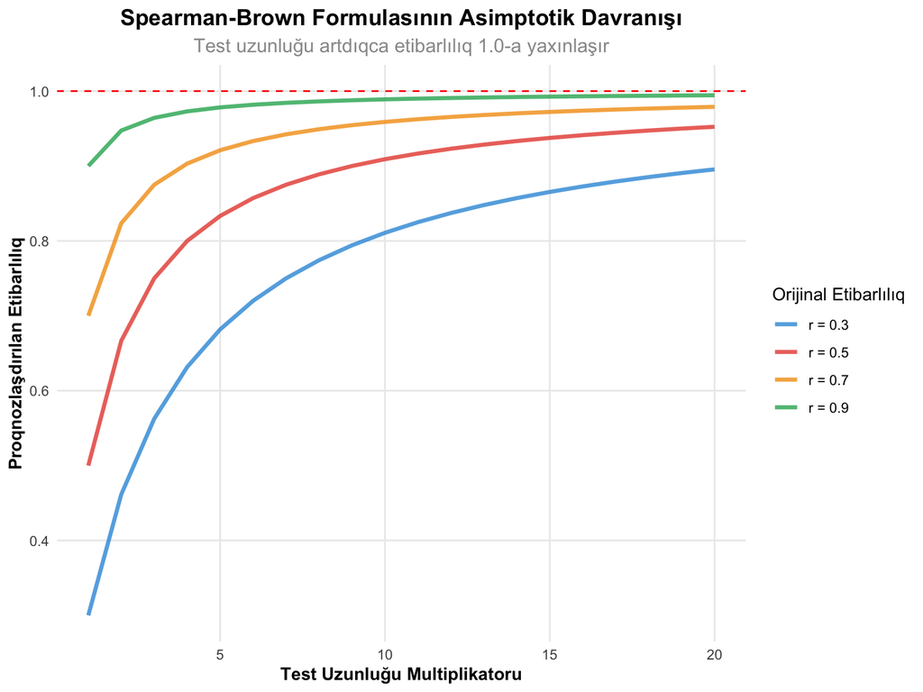

```r
# Asimptotik limitin vizuallaşdırılması
extreme_multipliers <- seq(1, 20, by = 1)
asymptotic_data <- expand.grid(
  Original_r = c(0.30, 0.50, 0.70, 0.90),
  Multiplier = extreme_multipliers
) %>%
  mutate(
    Predicted_r = spearman_brown(Original_r, Multiplier),
    Original_Label = paste("r =", Original_r)
  )

ggplot(asymptotic_data, aes(x = Multiplier, y = Predicted_r, color = Original_Label)) +
  geom_line(size = 1.2, alpha = 0.8) +
  geom_hline(yintercept = 1.0, linetype = "dashed", color = "red") +
  scale_color_manual(values = colors_basic[1:4]) +
  labs(title = "Spearman-Brown Formulasının Asimptotik Davranışı",
       subtitle = "Test uzunluğu artdıqca etibarlılıq 1.0-a yaxınlaşır",
       x = "Test Uzunluğu Multiplikatoru", y = "Proqnozlaşdırılan Etibarlılıq",
       color = "Orijinal Etibarlılıq") +
  theme_clean() +
  ylim(0.3, 1.0)
```

# 2 Optimal Test Uzunluğunun Təyini

## 2.1 Hədəf Etibarlılığına Görə Optimal Uzunluq

```r
# Tərsinə Spearman-Brown: Hədəf etibarlılığa çatmaq üçün lazım olan uzunluq
required_length <- function(target_reliability, current_reliability) {
  numerator <- target_reliability * (1 - current_reliability)
  denominator <- current_reliability * (1 - target_reliability)
  return(numerator / denominator)
}

# Müxtəlif ssenarilar üçün lazım olan uzunluq
current_reliabilities <- c(0.50, 0.60, 0.70, 0.75, 0.80)
target_reliabilities <- c(0.70, 0.80, 0.90, 0.95)

optimal_length_matrix <- expand.grid(
  Current_r = current_reliabilities,
  Target_r = target_reliabilities
) %>%
  filter(Target_r > Current_r) %>%
  mutate(
    Required_Multiplier = required_length(Target_r, Current_r),
    Required_Multiplier = round(Required_Multiplier, 2),
    Feasible = case_when(
      Required_Multiplier <= 2 ~ "Çox Asan",
      Required_Multiplier <= 3 ~ "Asan",
      Required_Multiplier <= 5 ~ "Orta",
      Required_Multiplier <= 10 ~ "Çətin",
      TRUE ~ "Çox Çətin"
    )
  )

kable(optimal_length_matrix, caption = "Hədəf Etibarlılığa Çatmaq üçün Lazım olan Test Uzunluğu")
```

Hədəf Etibarlılığa Çatmaq üçün Lazım olan Test Uzunluğu

| Current_r | Target_r | Required_Multiplier | Feasible |
| --- | --- | --- | --- |
| 0.50 | 0.70 | 2.33 | Asan |
| 0.60 | 0.70 | 1.56 | Çox Asan |
| 0.50 | 0.80 | 4.00 | Orta |
| 0.60 | 0.80 | 2.67 | Asan |
| 0.70 | 0.80 | 1.71 | Çox Asan |
| 0.75 | 0.80 | 1.33 | Çox Asan |
| 0.50 | 0.90 | 9.00 | Çətin |
| 0.60 | 0.90 | 6.00 | Çətin |
| 0.70 | 0.90 | 3.86 | Orta |
| 0.75 | 0.90 | 3.00 | Asan |
| 0.80 | 0.90 | 2.25 | Asan |
| 0.50 | 0.95 | 19.00 | Çox Çətin |
| 0.60 | 0.95 | 12.67 | Çox Çətin |
| 0.70 | 0.95 | 8.14 | Çətin |
| 0.75 | 0.95 | 6.33 | Çətin |
| 0.80 | 0.95 | 4.75 | Orta |

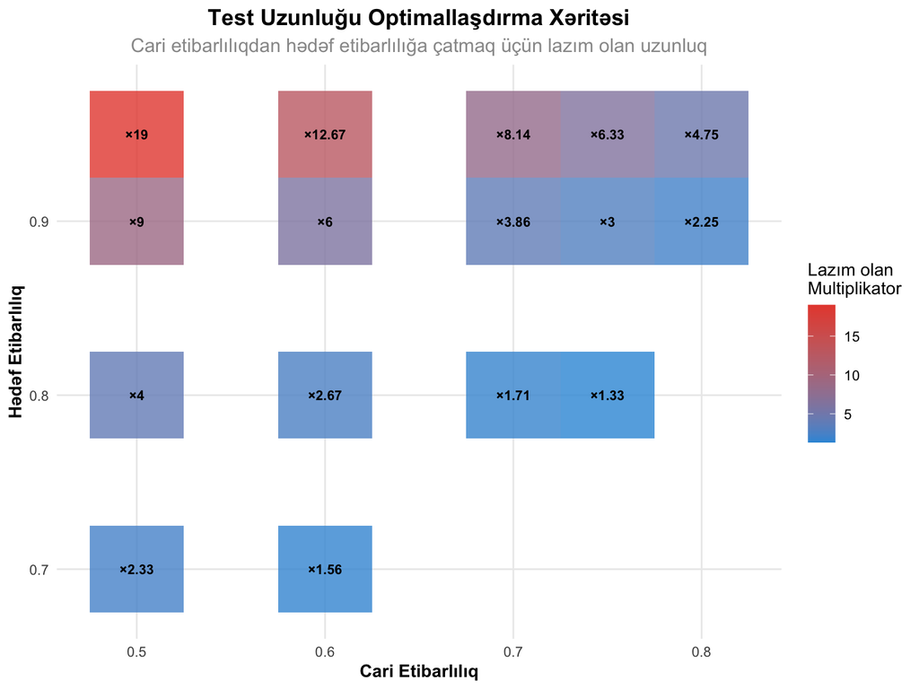

```r
# Optimal uzunluq xəritəsi
ggplot(optimal_length_matrix, aes(x = Current_r, y = Target_r, fill = Required_Multiplier)) +
  geom_tile(alpha = 0.8) +
  geom_text(aes(label = paste0("×", Required_Multiplier)), fontface = "bold", size = 3) +
  scale_fill_gradient(low = colors_basic[1], high = colors_basic[2],
                      name = "Lazım olan\nMultiplikator") +
  labs(title = "Test Uzunluğu Optimallaşdırma Xəritəsi",
       subtitle = "Cari etibarlılıqdan hədəf etibarlılığa çatmaq üçün lazım olan uzunluq",
       x = "Cari Etibarlılıq", y = "Hədəf Etibarlılıq") +
  theme_clean()
```

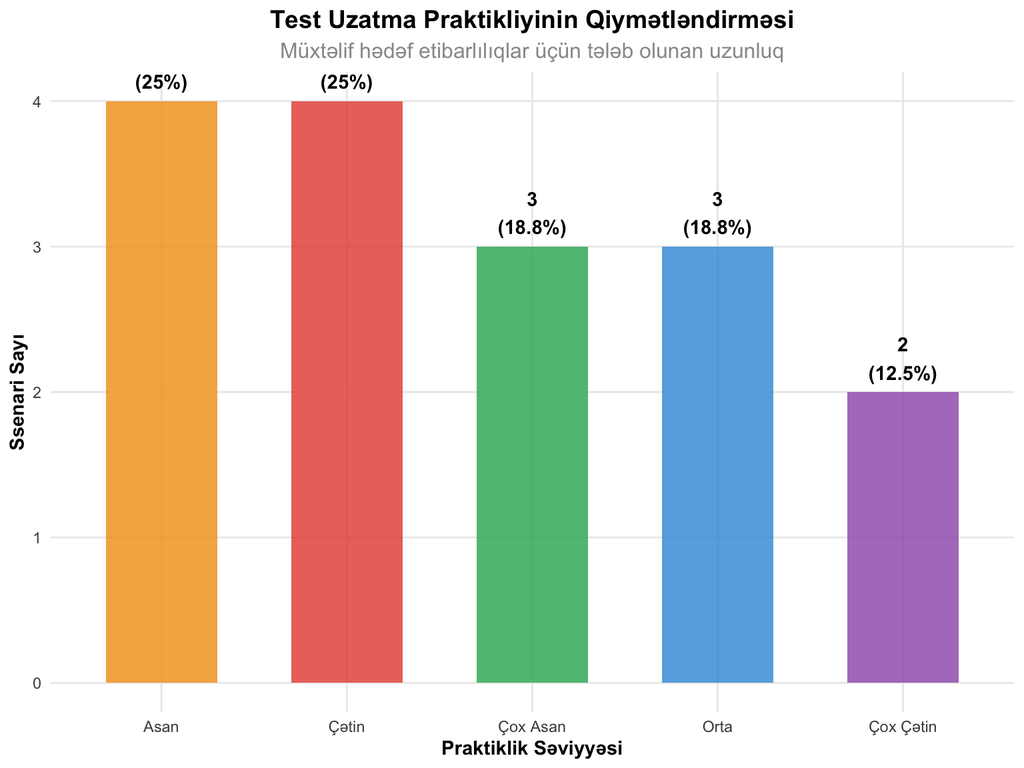

```r
# Praktiklik qiymətləndirməsi
feasibility_summary <- optimal_length_matrix %>%
  count(Feasible) %>%
  mutate(Percentage = round(n/sum(n)*100, 1))

ggplot(feasibility_summary, aes(x = reorder(Feasible, -n), y = n, fill = Feasible)) +
  geom_col(alpha = 0.8, width = 0.6) +
  geom_text(aes(label = paste0(n, "\n(", Percentage, "%)")),
            vjust = -0.3, fontface = "bold") +
  scale_fill_manual(values = c("Çox Asan" = colors_basic[4], "Asan" = colors_basic[3],
                               "Orta" = colors_basic[1], "Çətin" = colors_basic[2],
                               "Çox Çətin" = colors_basic[5])) +
  labs(title = "Test Uzatma Praktikliyinin Qiymətləndirməsi",
       subtitle = "Müxtəlif hədəf etibarlılıqlar üçün tələb olunan uzunluq",
       x = "Praktiklik Səviyyəsi", y = "Ssenari Sayı") +
  theme_clean() +
  theme(legend.position = "none")
```

## 2.2 Məhdudiyyətlər və Real Dünya Nəzəriyyələri

```r
# Real dünyada test uzunluğu məhdudiyyətləri
practical_constraints <- data.frame(
  Məhdudiyyət_Növü = c("Vaxt Məhdudiyyəti", "Tələbə Yorğunluğu", "İdarəetmə Çətinliyi",
                       "Maliyyə Məsrəfləri", "Məzmun Sərhədləri", "Motivasiya İtkisi"),
  Təsir_Başlanğıcı = c("15-20 bənd", "25-30 bənd", "50+ bənd",
                       "Test uzunluğuna görə", "Məzmun sahəsi", "30+ bənd"),
  Ciddi_Problem = c("40+ bənd", "50+ bənd", "100+ bənd",
                    "2x+ məsrəf", "Məzmun tükənməsi", "Sürətli cavablama"),
  Həll_Yolları = c("Kompyuter adaptiv", "Fasilələr", "Avtomatlaşdırma",
                   "Effektiv dizayn", "İçerik genişləndirmə", "Qamifikasiya"),
  Prioritet = c("Yüksək", "Yüksək", "Orta", "Orta", "Aşağı", "Orta")
)

kable(practical_constraints, caption = "Test Uzunluğunun Real Dünya Məhdudiyyətləri")
```

Test Uzunluğunun Real Dünya Məhdudiyyətləri

| Məhdudiyyət_Növü | Təsir_Başlanğıcı | Ciddi_Problem | Həll_Yolları | Prioritet |
| --- | --- | --- | --- | --- |
| Vaxt Məhdudiyyəti | 15-20 bənd | 40+ bənd | Kompyuter adaptiv | Yüksək |
| Tələbə Yorğunluğu | 25-30 bənd | 50+ bənd | Fasilələr | Yüksək |
| İdarəetmə Çətinliyi | 50+ bənd | 100+ bənd | Avtomatlaşdırma | Orta |
| Maliyyə Məsrəfləri | Test uzunluğuna görə | 2x+ məsrəf | Effektiv dizayn | Orta |
| Məzmun Sərhədləri | Məzmun sahəsi | Məzmun tükənməsi | İçerik genişləndirmə | Aşağı |
| Motivasiya İtkisi | 30+ bənd | Sürətli cavablama | Qamifikasiya | Orta |

```r
# Praktik vs Nəzəri optimal uzunluq
practical_optimal <- data.frame(
  Test_Məqsədi = c("Sürətli Skrining", "Standart Qiymətləndirmə", "Hərtərəfli Diaqnostika",
                   "Yüksək Stakes Qərar", "Tədqiqat Məqsədli", "Adaptiv Test"),
  Nəzəri_Optimal = c("5-10 bənd", "15-25 bənd", "30-50 bənd",
                     "40-80 bənd", "50-100 bənd", "Dəyişən"),
  Praktik_Optimal = c("3-8 bənd", "12-20 bənd", "25-40 bənd",
                      "30-60 bənd", "40-75 bənd", "5-40 bənd"),
  Kompromis_Səbəbi = c("Vaxt məhdudiyyəti", "İdarəetmə", "Yorğunluq",
                       "Dəqiqlik vs vaxt", "Resursa məhdudiyyəti", "Fərdiləşdirmə"),
  Target_Alpha = c("0.60-0.70", "0.70-0.80", "0.80-0.90",
                   "0.85-0.95", "0.90-0.95", "0.80-0.90")
)

kable(practical_optimal, caption = "Müxtəlif Test Məqsədləri üçün Optimal Uzunluq")
```

Müxtəlif Test Məqsədləri üçün Optimal Uzunluq

| Test_Məqsədi | Nəzəri_Optimal | Praktik_Optimal | Kompromis_Səbəbi | Target_Alpha |
| --- | --- | --- | --- | --- |
| Sürətli Skrining | 5-10 bənd | 3-8 bənd | Vaxt məhdudiyyəti | 0.60-0.70 |
| Standart Qiymətləndirmə | 15-25 bənd | 12-20 bənd | İdarəetmə | 0.70-0.80 |
| Hərtərəfli Diaqnostika | 30-50 bənd | 25-40 bənd | Yorğunluq | 0.80-0.90 |
| Yüksək Stakes Qərar | 40-80 bənd | 30-60 bənd | Dəqiqlik vs vaxt | 0.85-0.95 |
| Tədqiqat Məqsədli | 50-100 bənd | 40-75 bənd | Resursa məhdudiyyəti | 0.90-0.95 |
| Adaptiv Test | Dəyişən | 5-40 bənd | Fərdiləşdirmə | 0.80-0.90 |

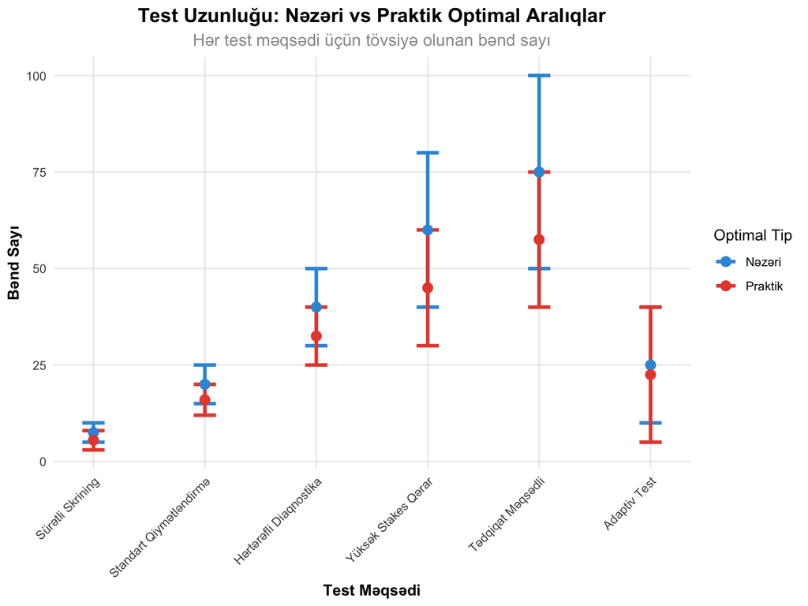

```r
# Test məqsədi vs uzunluq vizuallaşdırması
practical_data <- practical_optimal %>%
  mutate(
    Nəzəri_Min = c(5, 15, 30, 40, 50, 10),
    Nəzəri_Max = c(10, 25, 50, 80, 100, 40),
    Praktik_Min = c(3, 12, 25, 30, 40, 5),
    Praktik_Max = c(8, 20, 40, 60, 75, 40),
    Test_ID = 1:6
  )

practical_long <- practical_data %>%
  select(Test_Məqsədi, Test_ID, Nəzəri_Min, Nəzəri_Max, Praktik_Min, Praktik_Max) %>%
  pivot_longer(cols = c(Nəzəri_Min, Nəzəri_Max, Praktik_Min, Praktik_Max),
               names_to = "Tip", values_to = "Dəyər") %>%
  mutate(
    Kateqoriya = ifelse(grepl("Nəzəri", Tip), "Nəzəri", "Praktik"),
    Limit = ifelse(grepl("Min", Tip), "Min", "Max")
  ) %>%
  group_by(Test_Məqsədi, Test_ID, Kateqoriya) %>%
  summarise(Min_Val = min(Dəyər), Max_Val = max(Dəyər), .groups = 'drop')

ggplot(practical_long, aes(x = Test_ID, color = Kateqoriya)) +
  geom_errorbar(aes(ymin = Min_Val, ymax = Max_Val), width = 0.2, size = 1.2) +
  geom_point(aes(y = (Min_Val + Max_Val)/2), size = 3) +
  scale_color_manual(values = c("Nəzəri" = colors_basic[1], "Praktik" = colors_basic[2])) +
  scale_x_continuous(breaks = 1:6, labels = practical_data$Test_Məqsədi) +
  labs(title = "Test Uzunluğu: Nəzəri vs Praktik Optimal Aralıqlar",
       subtitle = "Hər test məqsədi üçün tövsiyə olunan bənd sayı",
       x = "Test Məqsədi", y = "Bənd Sayı", color = "Optimal Tip") +
  theme_clean() +
  theme(axis.text.x = element_text(angle = 45, hjust = 1))
```

# 3 Zaman və Etibarlılıq Balansı

## 3.1 Vaxt-Keyfiyyət Optimallaşdırması

```r
# Vaxt və etibarlılıq arasındakı balans analizi
time_reliability_analysis <- data.frame(
  Test_Uzunluğu = c(5, 10, 15, 20, 25, 30, 40, 50),
  Orta_Vaxt_Dəqiqə = c(8, 15, 22, 28, 35, 42, 55, 68),
  Gözlənilən_Alpha = spearman_brown(0.45, c(5, 10, 15, 20, 25, 30, 40, 50) / 10),
  Dəqiqə_başına_Alpha = round(spearman_brown(0.45, c(5, 10, 15, 20, 25, 30, 40, 50) / 10) /
                              c(8, 15, 22, 28, 35, 42, 55, 68), 4),
  Effektivlik_İndeksi = round((spearman_brown(0.45, c(5, 10, 15, 20, 25, 30, 40, 50) / 10) - 0.60) /
                              c(8, 15, 22, 28, 35, 42, 55, 68) * 100, 2),
  Praktiklik = c("Çox Yüksək", "Yüksək", "Yüksək", "Orta", "Orta", "Aşağı", "Aşağı", "Çox Aşağı")
)

kable(time_reliability_analysis, caption = "Vaxt və Etibarlılıq Balansının Analizi", digits = 3)
```

Vaxt və Etibarlılıq Balansının Analizi

| Test_Uzunluğu | Orta_Vaxt_Dəqiqə | Gözlənilən_Alpha | Dəqiqə_başına_Alpha | Effektivlik_İndeksi | Praktiklik |
| --- | --- | --- | --- | --- | --- |
| 5 | 8 | 0.290 | 0.036 | -3.87 | Çox Yüksək |
| 10 | 15 | 0.450 | 0.030 | -1.00 | Yüksək |
| 15 | 22 | 0.551 | 0.025 | -0.22 | Yüksək |
| 20 | 28 | 0.621 | 0.022 | 0.07 | Orta |
| 25 | 35 | 0.672 | 0.019 | 0.20 | Orta |
| 30 | 42 | 0.711 | 0.017 | 0.26 | Aşağı |
| 40 | 55 | 0.766 | 0.014 | 0.30 | Aşağı |
| 50 | 68 | 0.804 | 0.012 | 0.30 | Çox Aşağı |

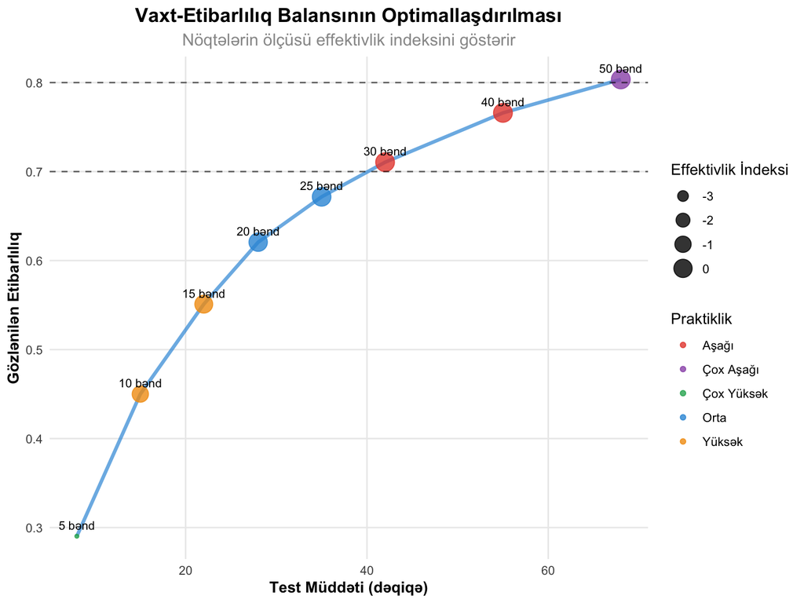

```r
# Pareto optimal nöqtələrinin vizuallaşdırılması
ggplot(time_reliability_analysis, aes(x = Orta_Vaxt_Dəqiqə, y = Gözlənilən_Alpha)) +
  geom_line(size = 1.2, color = colors_basic[1], alpha = 0.7) +
  geom_point(aes(color = Praktiklik, size = Effektivlik_İndeksi), alpha = 0.8) +
  geom_text(aes(label = paste0(Test_Uzunluğu, " bənd")),
            vjust = -0.8, size = 3) +
  scale_color_manual(values = c("Çox Yüksək" = colors_basic[4], "Yüksək" = colors_basic[3],
                                "Orta" = colors_basic[1], "Aşağı" = colors_basic[2],
                                "Çox Aşağı" = colors_basic[5])) +
  geom_hline(yintercept = c(0.70, 0.80), linetype = "dashed", alpha = 0.6) +
  labs(title = "Vaxt-Etibarlılıq Balansının Optimallaşdırılması",
       subtitle = "Nöqtələrin ölçüsü effektivlik indeksini göstərir",
       x = "Test Müddəti (dəqiqə)", y = "Gözlənilən Etibarlılıq",
       color = "Praktiklik", size = "Effektivlik İndeksi") +
  theme_clean()
```

```r
# Optimal balans nöqtəsinin təyini
optimal_balance <- time_reliability_analysis %>%
  filter(Gözlənilən_Alpha >= 0.70) %>%
  slice_max(Effektivlik_İndeksi, n = 1)

cat("Optimal Balans Nöqtəsi:\n")
```

```
## Optimal Balans Nöqtəsi:
```

```r
cat("Test uzunluğu:", optimal_balance$Test_Uzunluğu, "bənd\n")
```

```
## Test uzunluğu: 40 50 bənd
```

```r
cat("Müddət:", optimal_balance$Orta_Vaxt_Dəqiqə, "dəqiqə\n")
```

```
## Müddət: 55 68 dəqiqə
```

```r
cat("Etibarlılıq:", round(optimal_balance$Gözlənilən_Alpha, 3), "\n")
```

```
## Etibarlılıq: 0.766 0.804
```

```r
cat("Effektivlik:", optimal_balance$Effektivlik_İndeksi, "\n")
```

```
## Effektivlik: 0.3 0.3
```

## 3.2 Müxtəlif Kontekstlər üçün Balans Strategiyaları

```r
# Müxtəlif kontekstlər üçün optimal balans
context_strategies <- data.frame(
  Kontekst = c("Təcili Skrining", "Klinik Qiymətləndirmə", "Tədqiqat Tədbiqi",
               "Təhsil Qiymətləndirməsi", "İşə Qəbul Testi", "Monitoring"),
  Vaxt_Prioriteti = c("Çox Yüksək", "Orta", "Aşağı", "Orta", "Yüksək", "Yüksək"),
  Etibarlılıq_Prioriteti = c("Orta", "Çox Yüksək", "Çox Yüksək", "Yüksək", "Yüksək", "Orta"),
  Tövsiyə_Uzunluq = c("5-8 bənd", "25-40 bənd", "40-60 bənd", "15-25 bənd", "20-30 bənd", "8-12 bənd"),
  Target_Alpha = c("0.60-0.70", "0.85-0.95", "0.90-0.95", "0.75-0.85", "0.80-0.90", "0.65-0.75"),
  Maksimum_Vaxt = c("10 dəq", "60 dəq", "90+ dəq", "45 dəq", "30 dəq", "15 dəq")
)

kable(context_strategies, caption = "Kontekstə Görə Vaxt-Etibarlılıq Balans Strategiyaları")
```

Kontekstə Görə Vaxt-Etibarlılıq Balans Strategiyaları

| Kontekst | Vaxt_Prioriteti | Etibarlılıq_Prioriteti | Tövsiyə_Uzunluq | Target_Alpha | Maksimum_Vaxt |
| --- | --- | --- | --- | --- | --- |
| Təcili Skrining | Çox Yüksək | Orta | 5-8 bənd | 0.60-0.70 | 10 dəq |
| Klinik Qiymətləndirmə | Orta | Çox Yüksək | 25-40 bənd | 0.85-0.95 | 60 dəq |
| Tədqiqat Tədbiqi | Aşağı | Çox Yüksək | 40-60 bənd | 0.90-0.95 | 90+ dəq |
| Təhsil Qiymətləndirməsi | Orta | Yüksək | 15-25 bənd | 0.75-0.85 | 45 dəq |
| İşə Qəbul Testi | Yüksək | Yüksək | 20-30 bənd | 0.80-0.90 | 30 dəq |
| Monitoring | Yüksək | Orta | 8-12 bənd | 0.65-0.75 | 15 dəq |

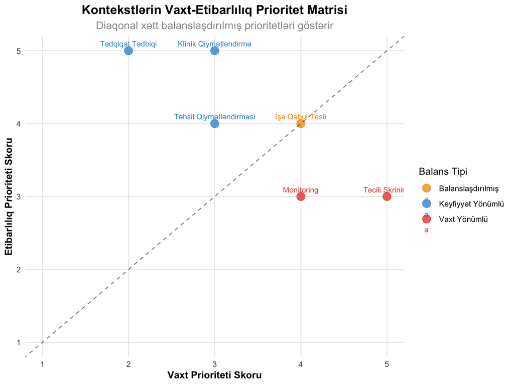

```r
# Prioritet matrisinin vizuallaşdırılması
priority_data <- context_strategies %>%
  mutate(
    Vaxt_Skoru = case_when(
      Vaxt_Prioriteti == "Çox Yüksək" ~ 5,
      Vaxt_Prioriteti == "Yüksək" ~ 4,
      Vaxt_Prioriteti == "Orta" ~ 3,
      Vaxt_Prioriteti == "Aşağı" ~ 2,
      TRUE ~ 1
    ),
    Etibarlılıq_Skoru = case_when(
      Etibarlılıq_Prioriteti == "Çox Yüksək" ~ 5,
      Etibarlılıq_Prioriteti == "Yüksək" ~ 4,
      Etibarlılıq_Prioriteti == "Orta" ~ 3,
      Etibarlılıq_Prioriteti == "Aşağı" ~ 2,
      TRUE ~ 1
    ),
    Balans_Tipi = case_when(
      Vaxt_Skoru > Etibarlılıq_Skoru ~ "Vaxt Yönümlü",
      Vaxt_Skoru < Etibarlılıq_Skoru ~ "Keyfiyyət Yönümlü",
      TRUE ~ "Balanslaşdırılmış"
    )
  )

ggplot(priority_data, aes(x = Vaxt_Skoru, y = Etibarlılıq_Skoru, color = Balans_Tipi)) +
  geom_point(size = 4, alpha = 0.8) +
  geom_text(aes(label = Kontekst), vjust = -0.8, size = 3) +
  geom_abline(intercept = 0, slope = 1, linetype = "dashed", alpha = 0.5) +
  scale_color_manual(values = c("Vaxt Yönümlü" = colors_basic[2],
                                "Keyfiyyət Yönümlü" = colors_basic[1],
                                "Balanslaşdırılmış" = colors_basic[3])) +
  labs(title = "Kontekstlərin Vaxt-Etibarlılıq Prioritet Matrisi",
       subtitle = "Diaqonal xətt balanslaşdırılmış prioritetləri göstərir",
       x = "Vaxt Prioriteti Skoru", y = "Etibarlılıq Prioriteti Skoru",
       color = "Balans Tipi") +
  theme_clean() +
  xlim(1, 5) + ylim(1, 5)
```

```r
# Balans tipi statistikaları
balance_summary <- priority_data %>%
  count(Balans_Tipi) %>%
  mutate(Faiz = round(n/sum(n)*100, 1))

kable(balance_summary, caption = "Kontekstlərin Balans Tipi Paylanması")
```

Kontekstlərin Balans Tipi Paylanması

| Balans_Tipi | n | Faiz |
| --- | --- | --- |
| Balanslaşdırılmış | 1 | 16.7 |
| Keyfiyyət Yönümlü | 3 | 50.0 |
| Vaxt Yönümlü | 2 | 33.3 |

# 4 R-da Test Uzunluğu Simulyasiyası

## 4.1 Hərtərəfli Simulyasiya Funksiyası

```r
# Test uzunluğu simulyasiya funksiyası
simulate_test_length_effects <- function(base_items = 10, base_reliability = 0.70,
                                       max_multiplier = 5, n_simulations = 100) {

  # Nəzəri proqnozlar
  multipliers <- seq(1, max_multiplier, by = 0.5)
  theoretical_predictions <- sapply(multipliers, function(m) {
    spearman_brown(base_reliability, m)
  })

  # Simulyasiya nəticələri
  simulation_results <- data.frame()

  for(mult in multipliers) {
    current_items <- round(base_items * mult)

    # Bir neçə simulyasiya aparaq
    sim_alphas <- numeric(n_simulations)

    for(sim in 1:n_simulations) {
      # Test məlumatları yaratmaq
      n_students <- 100

      # CTT modeli ilə məlumat generasiyası
      true_scores <- rnorm(n_students, 0, 1)
      test_data <- matrix(NA, nrow = n_students, ncol = current_items)

      for(i in 1:current_items) {
        # Hər bənd üçün çətinlik səviyyəsi
        item_difficulty <- runif(1, -1, 1)
        # Cavab ehtimalı (IRT 1PL modeli)
        prob <- 1 / (1 + exp(-(true_scores - item_difficulty)))
        test_data[, i] <- rbinom(n_students, 1, prob)
      }

      # Alpha hesablanması
      sim_alphas[sim] <- psych::alpha(test_data, check.keys = FALSE)$total$raw_alpha
    }

    # Nəticələri yadda saxlamaq
    temp_result <- data.frame(
      Multiplier = mult,
      Items = current_items,
      Theoretical_Alpha = spearman_brown(base_reliability, mult),
      Simulated_Alpha = mean(sim_alphas, na.rm = TRUE),
      Alpha_SD = sd(sim_alphas, na.rm = TRUE),
      Alpha_Min = min(sim_alphas, na.rm = TRUE),
      Alpha_Max = max(sim_alphas, na.rm = TRUE)
    )

    simulation_results <- rbind(simulation_results, temp_result)
  }

  return(simulation_results)
}

# Simulyasiyanı işə salaq
set.seed(123)
sim_results <- simulate_test_length_effects(base_items = 10, base_reliability = 0.70,
                                           max_multiplier = 4, n_simulations = 50)

kable(sim_results, caption = "Test Uzunluğu Simulyasiya Nəticələri", digits = 3)
```

Test Uzunluğu Simulyasiya Nəticələri

| Multiplier | Items | Theoretical_Alpha | Simulated_Alpha | Alpha_SD | Alpha_Min | Alpha_Max |
| --- | --- | --- | --- | --- | --- | --- |
| 1.0 | 10 | 0.700 | 0.672 | 0.052 | 0.521 | 0.785 |
| 1.5 | 15 | 0.778 | 0.746 | 0.033 | 0.634 | 0.800 |
| 2.0 | 20 | 0.824 | 0.799 | 0.025 | 0.728 | 0.855 |
| 2.5 | 25 | 0.854 | 0.833 | 0.019 | 0.797 | 0.872 |
| 3.0 | 30 | 0.875 | 0.858 | 0.018 | 0.803 | 0.883 |
| 3.5 | 35 | 0.891 | 0.869 | 0.018 | 0.819 | 0.905 |
| 4.0 | 40 | 0.903 | 0.887 | 0.016 | 0.845 | 0.916 |

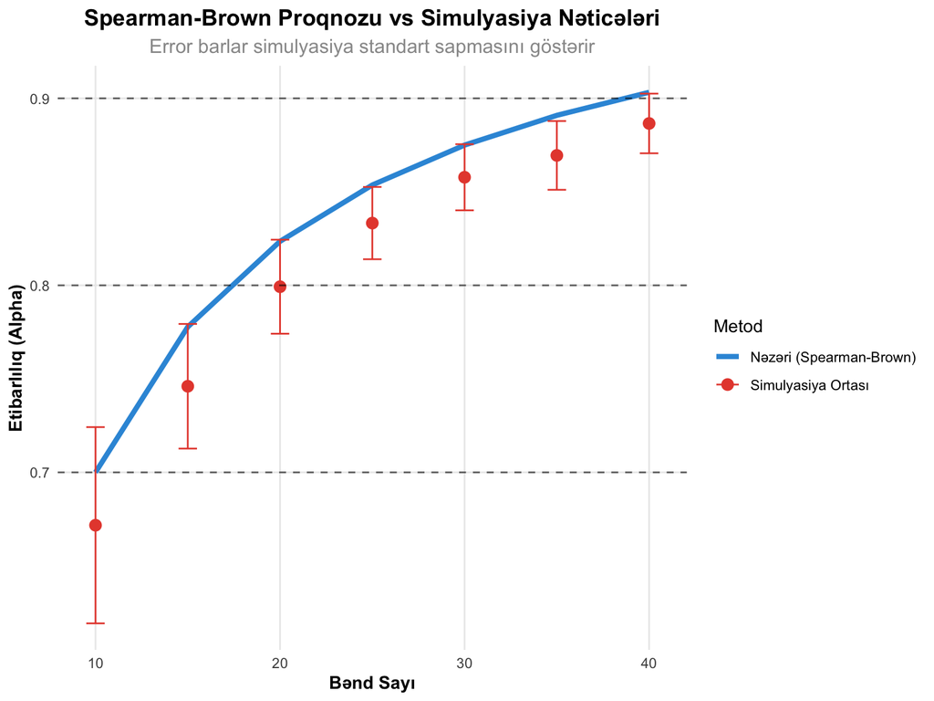

```r
# Nəzəri vs Simulyasiya müqayisəsi
ggplot(sim_results, aes(x = Items)) +
  geom_line(aes(y = Theoretical_Alpha, color = "Nəzəri (Spearman-Brown)"), size = 1.5) +
  geom_point(aes(y = Simulated_Alpha, color = "Simulyasiya Ortası"), size = 3) +
  geom_errorbar(aes(ymin = Simulated_Alpha - Alpha_SD,
                    ymax = Simulated_Alpha + Alpha_SD,
                    color = "Simulyasiya Ortası"), width = 1) +
  scale_color_manual(values = c("Nəzəri (Spearman-Brown)" = colors_basic[1],
                                "Simulyasiya Ortası" = colors_basic[2])) +
  geom_hline(yintercept = c(0.70, 0.80, 0.90), linetype = "dashed", alpha = 0.6) +
  labs(title = "Spearman-Brown Proqnozu vs Simulyasiya Nəticələri",
       subtitle = "Error barlar simulyasiya standart sapmasını göstərir",
       x = "Bənd Sayı", y = "Etibarlılıq (Alpha)", color = "Metod") +
  theme_clean()
```

```r
# Uyğunluq analizi
fit_analysis <- sim_results %>%
  mutate(
    Prediction_Error = abs(Theoretical_Alpha - Simulated_Alpha),
    Relative_Error = Prediction_Error / Theoretical_Alpha * 100
  )

cat("Spearman-Brown Formulasının Dəqiqliyi:\n")
```

```
## Spearman-Brown Formulasının Dəqiqliyi:
```

```r
cat("Orta mütləq xəta:", round(mean(fit_analysis$Prediction_Error), 4), "\n")
```

```
## Orta mütləq xəta: 0.0229
```

```r
cat("Orta nisbi xəta:", round(mean(fit_analysis$Relative_Error), 2), "%\n")
```

```
## Orta nisbi xəta: 2.81 %
```

```r
cat("Maksimum xəta:", round(max(fit_analysis$Prediction_Error), 4), "\n")
```

```
## Maksimum xəta: 0.0317
```

## 4.2 İnteraktiv Test Uzunluğu Kalkulyatoru

```r
# Test uzunluğu kalkulyator funksiyası
test_length_calculator <- function(current_reliability, target_reliability = NULL,
                                 target_length = NULL, current_length = 1) {

  if(!is.null(target_reliability)) {
    # Hədəf etibarlılığa çatmaq üçün lazım olan uzunluq
    required_mult <- required_length(target_reliability, current_reliability)
    required_items <- current_length * required_mult

    result <- data.frame(
      Cari_Etibarlılıq = current_reliability,
      Hədəf_Etibarlılıq = target_reliability,
      Cari_Uzunluq = current_length,
      Lazım_olan_Multiplikator = round(required_mult, 2),
      Lazım_olan_Bənd_Sayı = round(required_items, 0),
      Praktiklik = case_when(
        required_mult <= 1.5 ~ "Çox Asan",
        required_mult <= 2.5 ~ "Asan",
        required_mult <= 4.0 ~ "Orta",
        required_mult <= 8.0 ~ "Çətin",
        TRUE ~ "Çox Çətin"
      )
    )
  } else if(!is.null(target_length)) {
    # Müəyyən uzunluqda gözlənilən etibarlılıq
    multiplier <- target_length / current_length
    predicted_rel <- spearman_brown(current_reliability, multiplier)

    result <- data.frame(
      Cari_Etibarlılıq = current_reliability,
      Cari_Uzunluq = current_length,
      Hədəf_Uzunluq = target_length,
      Multiplikator = round(multiplier, 2),
      Gözlənilən_Etibarlılıq = round(predicted_rel, 3),
      Etibarlılıq_Artımı = round(predicted_rel - current_reliability, 3)
    )
  }

  return(result)
}

# Kalkulyator nümunələri
example_calculations <- data.frame(
  Ssenari = c("A", "B", "C", "D"),
  Cari_r = c(0.60, 0.70, 0.50, 0.80),
  Hədəf_r = c(0.80, 0.85, 0.75, 0.90),
  Cari_Uzunluq = c(15, 20, 10, 25)
)

calculator_results <- data.frame()
for(i in 1:nrow(example_calculations)) {
  temp_calc <- test_length_calculator(
    current_reliability = example_calculations$Cari_r[i],
    target_reliability = example_calculations$Hədəf_r[i],
    current_length = example_calculations$Cari_Uzunluq[i]
  )
  temp_calc$Ssenari <- example_calculations$Ssenari[i]
  calculator_results <- rbind(calculator_results, temp_calc)
}

kable(calculator_results, caption = "Test Uzunluğu Kalkulyatoru Nümunələri")
```

Test Uzunluğu Kalkulyatoru Nümunələri

| Cari_Etibarlılıq | Hədəf_Etibarlılıq | Cari_Uzunluq | Lazım_olan_Multiplikator | Lazım_olan_Bənd_Sayı | Praktiklik | Ssenari |
| --- | --- | --- | --- | --- | --- | --- |
| 0.6 | 0.80 | 15 | 2.67 | 40 | Orta | A |
| 0.7 | 0.85 | 20 | 2.43 | 49 | Asan | B |
| 0.5 | 0.75 | 10 | 3.00 | 30 | Orta | C |
| 0.8 | 0.90 | 25 | 2.25 | 56 | Asan | D |

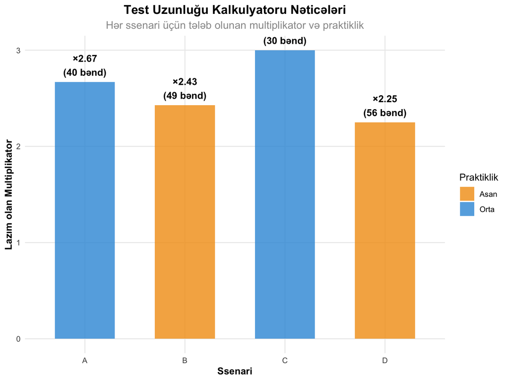

```r
# Kalkulyator nəticələrinin vizuallaşdırılması
ggplot(calculator_results, aes(x = Ssenari, y = Lazım_olan_Multiplikator, fill = Praktiklik)) +
  geom_col(alpha = 0.8, width = 0.6) +
  geom_text(aes(label = paste0("×", Lazım_olan_Multiplikator, "\n(",
                               Lazım_olan_Bənd_Sayı, " bənd)")),
            vjust = -0.3, fontface = "bold") +
  scale_fill_manual(values = c("Çox Asan" = colors_basic[4], "Asan" = colors_basic[3],
                               "Orta" = colors_basic[1], "Çətin" = colors_basic[2])) +
  labs(title = "Test Uzunluğu Kalkulyatoru Nəticələri",
       subtitle = "Hər ssenari üçün tələb olunan multiplikator və praktiklik",
       x = "Ssenari", y = "Lazım olan Multiplikator", fill = "Praktiklik") +
  theme_clean()
```

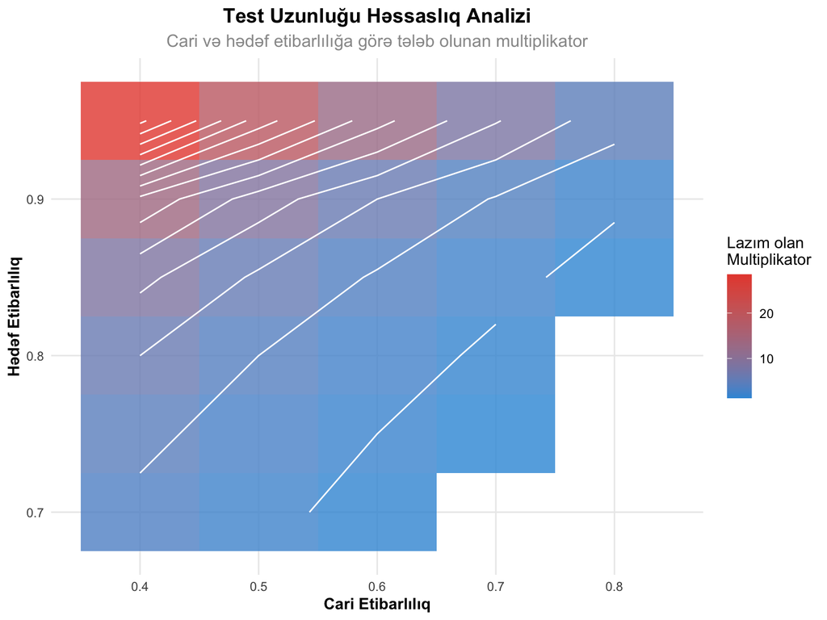

```r
# Həssaslıq analizi
sensitivity_analysis <- expand.grid(
  Current_r = seq(0.40, 0.80, by = 0.10),
  Target_r = seq(0.70, 0.95, by = 0.05)
) %>%
  filter(Target_r > Current_r) %>%
  mutate(
    Required_Mult = required_length(Target_r, Current_r),
    Feasible = Required_Mult <= 5
  )

ggplot(sensitivity_analysis, aes(x = Current_r, y = Target_r, fill = Required_Mult)) +
  geom_tile(alpha = 0.8) +
  geom_contour(aes(z = Required_Mult), color = "white", size = 0.5) +
  scale_fill_gradient(low = colors_basic[1], high = colors_basic[2],
                      name = "Lazım olan\nMultiplikator") +
  labs(title = "Test Uzunluğu Həssaslıq Analizi",
       subtitle = "Cari və hədəf etibarlılığa görə tələb olunan multiplikator",
       x = "Cari Etibarlılıq", y = "Hədəf Etibarlılıq") +
  theme_clean()
```

# 5 Praktik Tətbiq Strategiyaları

## 5.1 Test Inkişaf Dövrü

```r
# Test inkişafı dövrü strategiyası
development_phases <- data.frame(
  Mərhələ = c("İlkin Dizayn", "Pilot Test", "Sahə Testi", "Final Versiya", "Monitorinq"),
  Hədəf_Uzunluq = c("20-30 bənd", "15-20 bənd", "12-18 bənd", "10-15 bənd", "Sabit"),
  Hədəf_Alpha = c("0.60-0.70", "0.70-0.75", "0.75-0.80", "0.80-0.85", "0.80+"),
  Əsas_Fəaliyyət = c("Bənd yaratma", "İlkin test", "Optimallaşdırma", "Finallaşdırma", "Keyfiyyət nəzarəti"),
  Spearman_Brown_Rolu = c("Hədəf təyini", "Proqnozlaşdırma", "Optimallaşdırma", "Doğrulama", "Monitorinq"),
  Təxmini_Müddət = c("2-4 həftə", "1-2 həftə", "2-3 həftə", "1 həftə", "Davamlı")
)

kable(development_phases, caption = "Test İnkişaf Dövrünün Mərhələləri")
```

Test İnkişaf Dövrünün Mərhələləri

| Mərhələ | Hədəf_Uzunluq | Hədəf_Alpha | Əsas_Fəaliyyət | Spearman_Brown_Rolu | Təxmini_Müddət |
| --- | --- | --- | --- | --- | --- |
| İlkin Dizayn | 20-30 bənd | 0.60-0.70 | Bənd yaratma | Hədəf təyini | 2-4 həftə |
| Pilot Test | 15-20 bənd | 0.70-0.75 | İlkin test | Proqnozlaşdırma | 1-2 həftə |
| Sahə Testi | 12-18 bənd | 0.75-0.80 | Optimallaşdırma | Optimallaşdırma | 2-3 həftə |
| Final Versiya | 10-15 bənd | 0.80-0.85 | Finallaşdırma | Doğrulama | 1 həftə |
| Monitorinq | Sabit | 0.80+ | Keyfiyyət nəzarəti | Monitorinq | Davamlı |

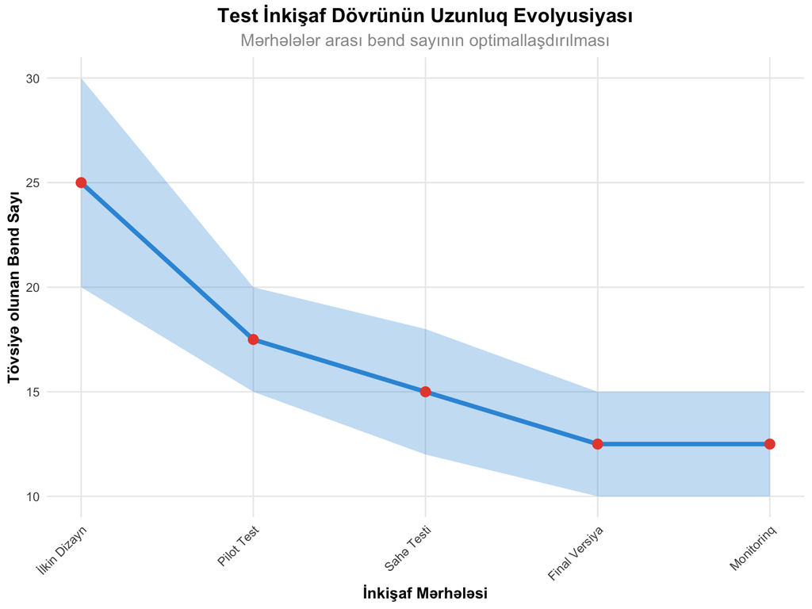

```r
# Mərhələ keçidlərinin vizuallaşdırılması
phase_data <- development_phases %>%
  mutate(
    Phase_Number = 1:5,
    Min_Items = c(20, 15, 12, 10, 10),
    Max_Items = c(30, 20, 18, 15, 15),
    Min_Alpha = c(0.60, 0.70, 0.75, 0.80, 0.80),
    Max_Alpha = c(0.70, 0.75, 0.80, 0.85, 0.90)
  )

ggplot(phase_data, aes(x = Phase_Number)) +
  geom_ribbon(aes(ymin = Min_Items, ymax = Max_Items), alpha = 0.3, fill = colors_basic[1]) +
  geom_line(aes(y = (Min_Items + Max_Items)/2), size = 1.5, color = colors_basic[1]) +
  geom_point(aes(y = (Min_Items + Max_Items)/2), size = 3, color = colors_basic[2]) +
  scale_x_continuous(breaks = 1:5, labels = development_phases$Mərhələ) +
  labs(title = "Test İnkişaf Dövrünün Uzunluq Evolyusiyası",
       subtitle = "Mərhələlər arası bənd sayının optimallaşdırılması",
       x = "İnkişaf Mərhələsi", y = "Tövsiyə olunan Bənd Sayı") +
  theme_clean() +
  theme(axis.text.x = element_text(angle = 45, hjust = 1))
```

```r
# Hər mərhələdə Spearman-Brown tətbiqi
sb_applications <- data.frame(
  Mərhələ = development_phases$Mərhələ,
  SB_Tətbiq_Növü = c("Hədəf uzunluq hesablanması", "Gözlənilən alpha proqnozu",
                     "Optimallaşdırma qərarları", "Final proqnoz doğrulanması",
                     "Dəyişiklik təsiri analizi"),
  Nümunə_Hesablama = c("ρ₇₀ üçün n = ?", "n=1.5 üçün ρ = ?",
                       "ρ₈₀ vs n balansı", "Final ρ doğrulanması",
                       "Δρ monitorinqi"),
  Qərar_Təsiri = c("İlkin bənd sayı", "Pilot ölçüsü", "Bənd seçimi",
                   "Final test forması", "Versiya yenilənməsi")
)

kable(sb_applications, caption = "Hər Mərhələdə Spearman-Brown Formulasının Tətbiqi")
```

Hər Mərhələdə Spearman-Brown Formulasının Tətbiqi

| Mərhələ | SB_Tətbiq_Növü | Nümunə_Hesablama | Qərar_Təsiri |
| --- | --- | --- | --- |
| İlkin Dizayn | Hədəf uzunluq hesablanması | ρ₇₀ üçün n = ? | İlkin bənd sayı |
| Pilot Test | Gözlənilən alpha proqnozu | n=1.5 üçün ρ = ? | Pilot ölçüsü |
| Sahə Testi | Optimallaşdırma qərarları | ρ₈₀ vs n balansı | Bənd seçimi |
| Final Versiya | Final proqnoz doğrulanması | Final ρ doğrulanması | Final test forması |
| Monitorinq | Dəyişiklik təsiri analizi | Δρ monitorinqi | Versiya yenilənməsi |

## 5.2 Keyfiyyət Təminatı Protokolu

```r
# Test keyfiyyəti təminatı protokolu
qa_protocol <- data.frame(
  Yoxlama_Nöqtəsi = c("İlkin Dizayn", "Pilot Nəticələri", "Sahə Test Məlumatları",
                      "Pre-launch", "Post-launch", "Dövri Yoxlama"),
  SB_Proqnozu = c("Hədəf α hesabla", "Pilot α əsasında proqnoz", "Sahə α doğrula",
                  "Final α təsdiqə", "Faktiki α müqayisə", "Trend α analizi"),
  Qəbul_Meyarı = c("±0.10 hədəfdən", "±0.05 proqnozdan", "±0.03 hədəfdən",
                   "±0.02 proqnozdan", "±0.05 planlaşdırılandan", "±0.03 əvvəlkindən"),
  Red_Halında = c("Dizaynı yenidən nəzərdən keçir", "Pilot təkrarla", "Bəndləri optimallaşdır",
                  "Launch təxirə sal", "Təcili araşdırma", "Versiya yenilə"),
  Məsul_Şəxs = c("Test Dizayneri", "Psixometrist", "Sahə Meneceri",
                 "Keyfiyyət Meneceri", "Məhsul Meneceri", "Analitik Komanda")
)

kable(qa_protocol, caption = "Test Keyfiyyəti Təminatı Protokolu")
```

Test Keyfiyyəti Təminatı Protokolu

| Yoxlama_Nöqtəsi | SB_Proqnozu | Qəbul_Meyarı | Red_Halında | Məsul_Şəxs |
| --- | --- | --- | --- | --- |
| İlkin Dizayn | Hədəf α hesabla | ±0.10 hədəfdən | Dizaynı yenidən nəzərdən keçir | Test Dizayneri |
| Pilot Nəticələri | Pilot α əsasında proqnoz | ±0.05 proqnozdan | Pilot təkrarla | Psixometrist |
| Sahə Test Məlumatları | Sahə α doğrula | ±0.03 hədəfdən | Bəndləri optimallaşdır | Sahə Meneceri |
| Pre-launch | Final α təsdiqə | ±0.02 proqnozdan | Launch təxirə sal | Keyfiyyət Meneceri |
| Post-launch | Faktiki α müqayisə | ±0.05 planlaşdırılandan | Təcili araşdırma | Məhsul Meneceri |
| Dövri Yoxlama | Trend α analizi | ±0.03 əvvəlkindən | Versiya yenilə | Analitik Komanda |

```r
# QA nəticələrinin izlənməsi
qa_tracking <- data.frame(
  Test_Versiyası = paste0("v", 1:6),
  Proqnozlaşdırılan_Alpha = c(0.75, 0.78, 0.82, 0.80, 0.83, 0.85),
  Faktiki_Alpha = c(0.72, 0.76, 0.84, 0.78, 0.81, 0.87),
  Proqnoz_Xətası = c(0.72, 0.76, 0.84, 0.78, 0.81, 0.87) -
                   c(0.75, 0.78, 0.82, 0.80, 0.83, 0.85),
  QA_Status = c("Qəbul", "Qəbul", "Qəbul", "Şərti Qəbul", "Qəbul", "Qəbul"),
  Təkmilləşdirmə = c("Yox", "Yox", "Yox", "Kiçik", "Yox", "Yox")
)

kable(qa_tracking, caption = "Test Versiyalarının QA İzləmə Nəticələri", digits = 3)
```

Test Versiyalarının QA İzləmə Nəticələri

| Test_Versiyası | Proqnozlaşdırılan_Alpha | Faktiki_Alpha | Proqnoz_Xətası | QA_Status | Təkmilləşdirmə |
| --- | --- | --- | --- | --- | --- |
| v1 | 0.75 | 0.72 | -0.03 | Qəbul | Yox |
| v2 | 0.78 | 0.76 | -0.02 | Qəbul | Yox |
| v3 | 0.82 | 0.84 | 0.02 | Qəbul | Yox |
| v4 | 0.80 | 0.78 | -0.02 | Şərti Qəbul | Kiçik |
| v5 | 0.83 | 0.81 | -0.02 | Qəbul | Yox |
| v6 | 0.85 | 0.87 | 0.02 | Qəbul | Yox |

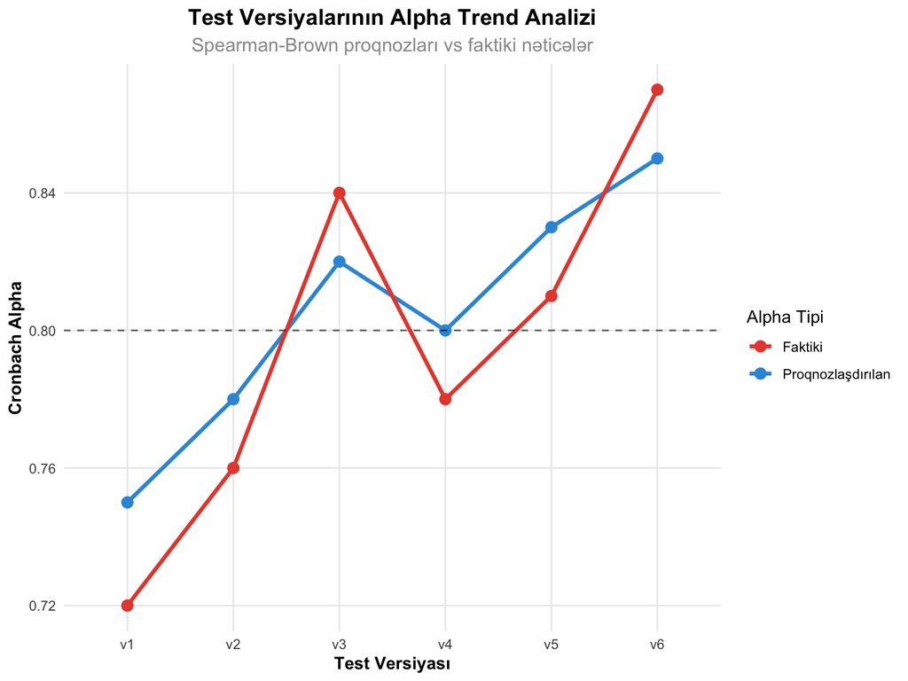

```r
# QA trend analizi
ggplot(qa_tracking, aes(x = Test_Versiyası)) +
  geom_line(aes(y = Proqnozlaşdırılan_Alpha, group = 1, color = "Proqnozlaşdırılan"), size = 1.2) +
  geom_line(aes(y = Faktiki_Alpha, group = 1, color = "Faktiki"), size = 1.2) +
  geom_point(aes(y = Proqnozlaşdırılan_Alpha, color = "Proqnozlaşdırılan"), size = 3) +
  geom_point(aes(y = Faktiki_Alpha, color = "Faktiki"), size = 3) +
  scale_color_manual(values = c("Proqnozlaşdırılan" = colors_basic[1],
                                "Faktiki" = colors_basic[2])) +
  geom_hline(yintercept = 0.80, linetype = "dashed", alpha = 0.6) +
  labs(title = "Test Versiyalarının Alpha Trend Analizi",
       subtitle = "Spearman-Brown proqnozları vs faktiki nəticələr",
       x = "Test Versiyası", y = "Cronbach Alpha", color = "Alpha Tipi") +
  theme_clean()
```

```r
# Proqnoz dəqiqliyi statistikaları
cat("Proqnoz Dəqiqliyi Analizi:\n")
```

```
## Proqnoz Dəqiqliyi Analizi:
```

```r
cat("Orta mütləq xəta:", round(mean(abs(qa_tracking$Proqnoz_Xətası)), 3), "\n")
```

```
## Orta mütləq xəta: 0.022
```

```r
cat("RMSE:", round(sqrt(mean(qa_tracking$Proqnoz_Xətası^2)), 3), "\n")
```

```
## RMSE: 0.022
```

```r
cat("Qəbul edilən versiya faizi:", round(mean(qa_tracking$QA_Status == "Qəbul") * 100, 1), "%\n")
```

```
## Qəbul edilən versiya faizi: 83.3 %
```

# 6 Dərsin Xülasəsi

## 6.1 Əsas Nəticələr

**Spearman-Brown Formulası:** - ✓ **ρₙₙ = nρ₁₁ / [1 + (n-1)ρ₁₁]** - test uzunluğunun etibarlılığa təsiri - ✓ **Asimptotik davranış** - uzunluq artdıqca etibarlılıq 1.0-a yaxınlaşır  
- ✓ **İki istiqamətli** - həm proqnozlaşdırma, həm optimal uzunluq təyini

**Optimal Test Uzunluğu:** - ✓ **Hədəf etibarlılıq** əsasında lazım olan uzunluq hesablanması - ✓ **Praktik məhdudiyyətlər** - vaxt, yorğunluq, maliyyə - ✓ **Kontekstə görə fərqli** - sürətli skrining vs hərtərəfli qiymətləndirmə

**Praktik Tətbiqlər:** - ✓ Test inkişaf dövrünün hər mərhələsində istifadə - ✓ Keyfiyyət təminatı və QA protokolları - ✓ R simulyasiyaları ilə nəzəri proqnozların doğrulanması

# 7 Ev Tapşırığı

## 7.1 Tapşırıq 1: Nəzəri Hissə (30 xal)

1. **Spearman-Brown formulasının nəzəri əsasları** nədir? Formulanın hər komponentinin psixometrik mənasını izah edin. (300 söz)
2. **Test uzunluğu artırılmasının məhdudiyyətləri** hansılardır? Real dünyada nə vaxt Spearman-Brown proqnozları tutmur? (250 söz)
3. **Optimal test uzunluğu** necə təyin edilir? Vaxt və etibarlılıq arasındakı balansı necə optimallaşdırmaq olar? (250 söz)

## 7.2 Tapşırıq 2: R Praktik Analizi (40 xal)

```r
# Test uzunluğu analizi tapşırığı
set.seed(sizin_tələbə_nömrəniz)

# Verilmiş başlanğıc parametrlər
current_test_length <- 12
current_reliability <- 0.65
target_reliabilities <- c(0.70, 0.75, 0.80, 0.85, 0.90)

# TAPŞİRIQLAR:
# 1. Hər hədəf etibarlılıq üçün lazım olan test uzunluğunu hesablayın
# 2. Müxtəlif test uzunluqları (5-50 bənd) üçün Spearman-Brown proqnozları
# 3. Monte Carlo simulyasiya aparın (50 təkrar) və nəzəri proqnozlarla müqayisə edin
# 4. Optimal vaxt-etibarlılıq balansını təyin edin
# 5. Praktik tövsiyələr hazırlayın

# HƏLL STRUKTURU:
# 1. Spearman-Brown hesablamaları
spearman_brown_results <- data.frame(
  Target_Alpha = target_reliabilities,
  Required_Multiplier = , # Doldurun
  Required_Items = , # Doldurun
  Feasibility = # Doldurun ("Asan"/"Orta"/"Çətin")
)

# 2. Test uzunluğu proyeksiyaları
test_lengths <- seq(5, 50, by = 5)
length_projections <- data.frame(
  Test_Length = test_lengths,
  Predicted_Alpha = , # Doldurun
  Estimated_Time_Minutes = , # Doldurun (fərz edin: 1.5 dəq/bənd)
  Efficiency_Index = # Doldurun (alpha artımı / vaxt)
)

# 3. Simulyasiya analizi
simulate_reliability <- function(n_items, n_students = 100) {
  # Sadə simulyasiya kodunu yazın
  # CTT əsasında test məlumatları yaradın
  # Alpha hesablayın
}

# CAVABLARINIZI VERİN:
print("Optimal test uzunluğu:")
print("Tövsiyə olunan etibarlılıq hədəfi:")
print("Gözlənilən test müddəti:")

# BONUS: Həssaslıq analizi - cari etibarlılıq ±0.05 dəyişərsə nə olur?
```

## 7.3 Tapşırıq 3: Test Optimallaşdırma Planı (30 xal)

Aşağıdakı real ssenari üçün hərtərəfli test optimallaşdırma planı hazırlayın:

**Ssenari:** Universitetə qəbul imtahanı - Cari test: 20 bənd, α = 0.72 - Hədəf: α ≥ 0.85  
- Məhdudiyyətlər: Maksimum 90 dəqiqə, bənd başına 3-4 dəqiqə

**Tələb olunanlar:**

1. **Spearman-Brown analizi** (200 söz)
   - Lazım olan test uzunluğu hesablanması
   - Müxtəlif ssenarilərin müqayisəsi
   - Praktiklik qiymətləndirməsi
2. **Alternativ strategiyalar** (250 söz)
   - Bənd keyfiyyətini artırma vs uzunluq artırma
   - İki mərhələli test strategiyası
   - Adaptiv test imkanları
3. **Tövsiyə və tətbiq planı** (200 söz)
   - Final tövsiyə və əsaslandırma
   - Tətbiq mərhələləri və vaxt çərçivəsi
   - Risk analizi və alternativ planlar

# 8 Növbəti Dərslərə Hazırlıq

## 8.1 Dərs 15: “Parallel Test Etibarlılığı”

Növbəti dərsdə öyrənəcəklər:

- ✓ Parallel testlərin xüsusiyyətləri və şərtləri
- ✓ Parallel test etibarlılığının hesablanması
- ✓ Tau-ekvivalent və congeneric testlər
- ✓ Parallel test yaratma strategiyaları

## 8.2 Dərs 16: “Split-Half Etibarlılıq”

Sonrakı mövzular:

- ✓ Testin yarıya bölünməsi metodları
- ✓ Split-half korrelyasiyasının hesablanması
- ✓ Spearman-Brown düzəlişinin tətbiqi
- ✓ Müxtəlif bölünmə strategiyalarının müqayisəsi

# 9 Əlavə Tədqiqat Materialları

## 9.1 Əsas Ədəbiyyat

**Məcburi oxu:** - Allen, M.J., & Yen, W.M. (2002). *Introduction to Measurement Theory*. Fəsil 4: “Reliability” - Crocker, L., & Algina, J. (2008). Fəsil 6: “Procedures for Estimating Reliability”

**Tövsiyə olunan:** - Lord, F.M., & Novick, M.R. (1968). Fəsil 4: “The Spearman-Brown Formula” - McDonald, R.P. (1999). *Test Theory: A Unified Treatment*. Fəsil 7

## 9.2 Online Resurslar

**R Paketləri:** - `psych::alpha()` - etibarlılıq hesablamaları - `psych::splitHalf()` - split-half analizi - `reliability` - hərtərəfli etibarlılıq analizi

**Kalkulyatorlar:** - [Online Spearman-Brown Calculator](https://www.socscistatistics.com/tests/spearman-brown/) - [Test Length Optimizer](https://www.assessment.com/test-length)

## 9.3 Təbriklər!

Test uzunluğu və etibarlılıq arasındakı əlaqəni uğurla öyrəndiniz! İndi Spearman-Brown formulasını praktik şəraitlərdə tətbiq edə bilirsiniz.

**Növbəti dərsdə parallel test etibarlılığını öyrənəcəksiniz! 📏**

*Bu dərs Allen və Yen (2002) və klassik psixometrik nəzəriyyə mənbələrinə əsaslanır.*

**Son yenilənmə:** 2025-07-18 | **Versiya:** 1.0